# IA para Científicos Sociales

Sesión 2.2: Regresión y predicción

Danilo Freire

danilofreire@gmail.com

Department of Data and Decision Sciences  
Emory University

# Regresión y predicción

## Agenda de la sesión

**Primera parte**

- Predicción vs. explicación: las “dos culturas”
- Regresión lineal y sus limitaciones
- El problema del sobreajuste revisitado
- Regularización: LASSO, Ridge, Elastic Net

**Segunda parte**

- Ajuste de hiperparámetros (tuning)
- Ingeniería de variables para datos sociales
- Aplicaciones en ciencias sociales
- Comparación con otros métodos

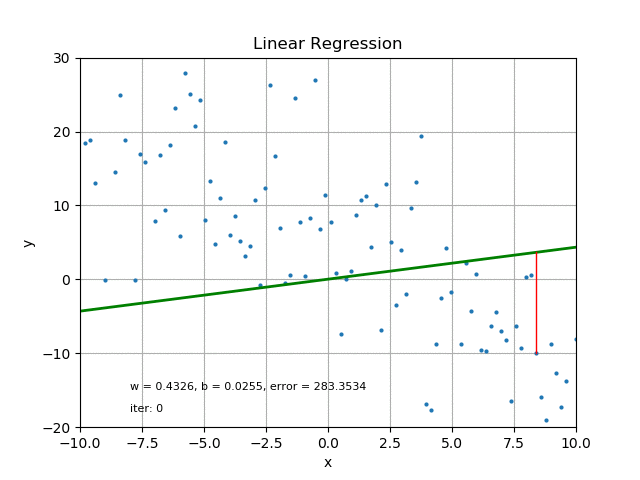

# Predicción vs. explicación

## El debate central en ciencias sociales

- Breiman (2001), “[Statistical Modeling: The Two Cultures](https://doi.org/10.1214/ss/1009213726)”:
  - Modelo de datos: se asume un modelo generador, se estiman parámetros ($\hat{\beta}$). Foco en identificación causal
  - Modelo algorítmico: caja negra, se optimiza la predicción ($\hat{y}$). Foco en generalización a datos nuevos
- En ciencias sociales solemos explicar, pero predecir deserción escolar o focalizar intervenciones también requiere buenos modelos

**Ejemplos**

| Pregunta | Tipo |
| --- | --- |
| ¿Las becas aumentaron la asistencia escolar? | Explicación |
| ¿Qué estudiantes van a desertar? | Predicción |
| ¿La vacunación redujo la mortalidad? | Explicación |
| ¿Qué pacientes necesitan cuidados intensivos? | Predicción |

¡Ambos son valiosos! El ML aporta herramientas de predicción que complementan los métodos causales

## ¿Por qué la regresión lineal “clásica” no es suficiente para predecir?

- La regresión lineal (OLS) minimiza el error en los datos de entrenamiento
- Pero si tenemos muchas variables relativas al número de observaciones, OLS se ajusta demasiado al ruido
- Ejemplo: con 50 variables y 100 observaciones, OLS encuentra coeficientes que parecen funcionar pero no generalizan
- OLS no tiene un mecanismo para descartar variables irrelevantes ni para reducir coeficientes inflados
- Solución: regularización, que agrega una penalización por la magnitud de los coeficientes

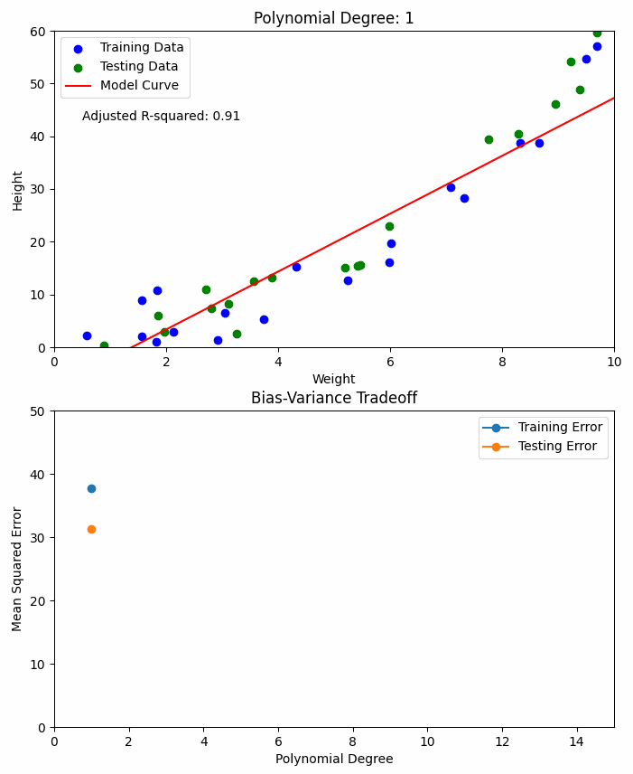

# Regularización

## La idea de la regularización

- Regularización = agregar una penalización por la complejidad del modelo
- En la regresión OLS, minimizamos el error:

$$\min \sum_{i=1}^{n} (y_i - \hat{y}_i)^2$$

- Con regularización, agregamos un término de penalización:

$$\min \sum_{i=1}^{n} (y_i - \hat{y}_i)^2 + \lambda \cdot \text{penalización}(\beta)$$

- $\lambda$ controla la fuerza de la penalización:
  - $\lambda = 0$: sin penalización (OLS clásico)
  - $\lambda$ grande: penalización fuerte (coeficientes se reducen hacia 0)
- El truco está en elegir el $\lambda$ óptimo (por validación cruzada)

**Elegir λ es moverse por el equilibrio sesgo-varianza**

- λ chico → bajo sesgo, alta varianza (sobreajuste)
- λ grande → alto sesgo, baja varianza (subajuste)
- El mejor λ está en el punto intermedio

## LASSO (L1) y Ridge (L2)

**LASSO (L1, [Tibshirani, 1996](https://doi.org/10.1111/j.2517-6161.1996.tb02080.x)): suma de valores absolutos**

$$\min \sum (y_i - \hat{y}_i)^2 + \lambda \sum |\beta_j|$$

- Reduce algunos coeficientes exactamente a cero → selecciona variables automáticamente
- Útil cuando solo algunas variables son relevantes

**Ridge (L2): suma de cuadrados**

$$\min \sum (y_i - \hat{y}_i)^2 + \lambda \sum \beta_j^2$$

- No elimina variables: las reduce pero nunca a cero exacto
- Útil con variables correlacionadas (multicolinealidad)

**LASSO vs Ridge con λ = 0.1**

```
                LASSO    Ridge
edad             0.023   0.018
educacion        0.085   0.072
ingreso          0.041   0.035
zona             0.000   0.008
genero           0.000   0.003
confianza_gob    0.019   0.015
satisf_democ     0.052   0.044
percepcion_econ  0.000   0.009

LASSO eliminó 3 variables;
Ridge mantuvo todas con
coeficientes pequeños
```

## La penalización, con números

- La penalización es una función: todos los coeficientes → un número
- Ese número mide qué tan grandes son los coeficientes juntos
- Se suma al error: el modelo minimiza error + λ · penalización
- Se recalcula en cada combinación que el optimizador prueba
- Un coeficiente grande baja el error, pero sube la penalización
- Con λ grande no compensa, gana la simplicidad

Con los coeficientes anteriores:

```
penalización(β): el tamaño de los coeficientes (sin λ)
  LASSO:  Σ|βⱼ|  = |0.023|+|0.085|+...+0  = 0.220
  Ridge:  Σβⱼ²   = 0.018²+0.072²+...+0.009² = 0.009

término que se suma al error = λ · penalización
  (el mismo λ = 0.1, una sola vez)
  LASSO:  0.1 · 0.220 = 0.022
  Ridge:  0.1 · 0.009 = 0.0009
```

- Los coeficientes ya son la solución para λ = 0.1; multiplicar por λ no penaliza de nuevo, solo calcula el valor de ese término
- Al elevar al cuadrado, Ridge castiga sobre todo a los coeficientes grandes y casi ignora los chicos: por eso nunca los lleva a cero exacto
- El valor absoluto de LASSO cobra lo mismo por unidad sin importar el tamaño: por eso empuja los chicos hasta cero

## Elastic Net: lo mejor de ambos

- Elastic Net ([Zou y Hastie, 2005](https://doi.org/10.1111/j.1467-9868.2005.00503.x)) combina LASSO (L1) y Ridge (L2):

$$\min \sum (y_i - \hat{y}_i)^2 + \lambda \left[ \alpha \sum |\beta_j| + (1-\alpha) \sum \beta_j^2 \right]$$

- Dos hiperparámetros:
  - $\lambda$: fuerza general de la penalización
  - $\alpha$: mezcla entre LASSO y Ridge
  - $\alpha = 1$: LASSO puro
  - $\alpha = 0$: Ridge puro
  - $0 < \alpha < 1$: Elastic Net
- Selecciona variables (como LASSO) pero maneja mejor las correlaciones (como Ridge)
- En la práctica, Elastic Net suele funcionar mejor que LASSO o Ridge por separado

|  | LASSO | Ridge | Elastic Net |
| --- | --- | --- | --- |
| Penalización | L1 ($\|\beta\|$) | L2 ($\beta^2$) | L1 + L2 |
| Selección | Sí | No | Sí |
| Correlación | Problemas | Bien | Bien |
| Hiperparámetros | $\lambda$ | $\lambda$ | $\lambda$, $\alpha$ |

**Regla general:**

- Pocas variables importantes → LASSO
- Muchas variables correlacionadas → Ridge
- No estoy seguro → Elastic Net

## El sesgo de la regularización

- OLS es insesgado: bajo los supuestos clásicos (Gauss-Markov), en promedio sus coeficientes aciertan el efecto verdadero
- Ridge, LASSO y Elastic Net son sesgados a propósito: la penalización empuja todos los coeficientes hacia cero (*shrinkage*)
- Ese sesgo es el precio que pagamos por reducir la varianza y predecir mejor en datos nuevos
- Un coeficiente penalizado ya no es una estimación insesgada del efecto: está encogido hacia cero

| Objetivo | Herramienta | Coeficientes |
| --- | --- | --- |
| Explicar | OLS (MCO) | Insesgados, interpretables |
| Predecir | LASSO, Ridge, Elastic Net | Sesgados, no causales |

- Para estimar el efecto de una variable: OLS
- Para la mejor predicción: regularización
- La regularización vive del lado de predecir, no de explicar

## Regularización en R

Con tidymodels + glmnet:

```r
# LASSO (mixture = 1)
modelo_lasso <- linear_reg(penalty = 0.1, mixture = 1) |>
  set_engine("glmnet") |>
  set_mode("regression")

# Ridge (mixture = 0)
modelo_ridge <- linear_reg(penalty = 0.1, mixture = 0) |>
  set_engine("glmnet") |>
  set_mode("regression")

# Elastic Net (mixture entre 0 y 1)
modelo_enet <- linear_reg(penalty = 0.1, mixture = 0.5) |>
  set_engine("glmnet") |>
  set_mode("regression")

# Ajustar cualquiera de ellos (misma sintaxis)
ajuste <- fit(modelo_lasso, satisfaccion_vida ~ ., data = datos_train)
```

- `penalty` = $\lambda$ (fuerza de la penalización)
- `mixture` = $\alpha$ (1 = LASSO, 0 = Ridge, entre 0 y 1 = Elastic Net)
- En la práctica, usamos validación cruzada para encontrar los mejores valores de `penalty` y `mixture`

# Ingeniería de variables

## Ingeniería de variables para datos sociales

Crear, transformar o seleccionar variables para mejorar el modelo:

- Variables categóricas: dummies (one-hot encoding)
- Variables ordinales: ¿numéricas o categóricas?
- Interacciones: productos entre variables (`edad * educacion`)
- Transformaciones: `log(ingreso)`, `edad^2` para no linealidades
- Discretización: edad → grupos etarios
- Imputación: reemplazar valores faltantes (mediana, KNN)
- https://recipes.tidymodels.org/reference/index.html

**Con recipes de tidymodels:**

```r
# Los pasos más comunes (hay muchos más step_*: ver el enlace de arriba)
receta <- recipe(voto ~ ., data = datos_train) |>
  step_impute_median(all_numeric_predictors()) |>   # imputar faltantes
  step_dummy(all_nominal_predictors()) |>           # categóricas → dummies
  step_normalize(all_numeric_predictors()) |>       # media=0, sd=1
  step_zv(all_predictors()) |>                      # quitar varianza cero
  step_interact(terms = ~ edad:educacion_anios)     # interacción edad×educación
```

## Una receta es un plan, no los datos

- `recipe()` no transforma nada todavía: guarda la lista de pasos para ejecutarla después
- `prep()` calcula con los datos de entrenamiento los valores que cada paso necesita: medianas para imputar, medias y desvíos para normalizar
- `juice()` devuelve el conjunto de entrenamiento ya transformado
- `bake()` aplica esa misma receta a datos nuevos, con los valores aprendidos del entrenamiento
- Separar el plan de su ejecución es lo que evita el data leakage: el test set nunca influye en las medianas ni en los desvíos

```r
# Inspeccionar el resultado de la receta
receta |>
  prep() |>
  juice() |>
  glimpse()

# Aplicar la receta a datos nuevos
bake(prep(receta), new_data = datos_test)
```

Dentro de un `workflow()` esto pasa automáticamente. Usamos `prep()` y `juice()` solo para revisar que la receta haya hecho lo que esperábamos

## El flujo completo: `workflow()`

- En tidymodels, `recipe` y `model` se combinan en un `workflow()`
- El workflow conecta el preprocesamiento con el modelo en un solo objeto
- Ventaja: se aplica automáticamente a datos nuevos, sin repetir pasos manualmente

```r
# Combinar receta + modelo en un workflow
# (en los labs lo verán como wf_<modelo>:
# wf_lasso, wf_rf, etc.)
wf_lasso <- workflow() |>
  add_recipe(receta) |>
  add_model(modelo_lasso)

# Ajustar todo junto
ajuste <- fit(wf_lasso, data = datos_train)

# Predecir con datos nuevos
predicciones <- predict(ajuste,
                        new_data = datos_test)
```

**Evaluación final con `last_fit()`:**

```r
# Evaluar en el test set (una sola vez)
resultado <- last_fit(wf_lasso,
                      split = datos_split)

# Métricas finales
collect_metrics(resultado)

# Ver predicciones
collect_predictions(resultado)
```

`last_fit()` ajusta con todo el train set y evalúa con el test set en un solo paso. Es la forma recomendada de obtener las métricas finales del modelo

Es el `fit()` y el `predict()` de la izquierda en una sola llamada, pero sobre el split, no sobre un data frame: por eso el test se toca una sola vez

## ¿Qué hace un `workflow()` por dentro?

- Un `workflow()` empaqueta la receta y el modelo en un solo objeto
- Antes teníamos pasos sueltos: preparar la receta, aplicarla al train, ajustar el modelo, aplicar la receta al test, predecir. Es fácil equivocarse en el orden
- El workflow los une: cuando llamamos a `fit()` o `predict()`, aplica la receta y después el modelo en el orden correcto, por sí solo
- Garantiza que el test pase por exactamente la misma transformación que el train, con las medianas y desvíos aprendidos solo del train: así se evita el *data leakage*
- Un solo objeto viaja por todo el flujo: ajustar, predecir, tunear y evaluar

**Un objeto, todo el flujo:**

```
   receta   +   modelo
        │
        ▼
     workflow()
        │
   ┌────┴─────┐
 fit()    last_fit()
   │          │
   ▼          ▼
 ajuste    métricas
   │        en test
   ▼
 predict(datos nuevos)
```

`add_recipe()` y `add_model()` son las dos piezas; el workflow sabe aplicarlas en orden

# Ajuste de hiperparámetros para regularización

## ¿Cómo elegir λ (penalty)?

- $\lambda$ controla la fuerza de la regularización
- El valor correcto depende de los datos, así que lo buscamos empíricamente

**Estrategia práctica (3 pasos):**

1. Definir una grilla de valores candidatos de $\lambda$ (en escala logarítmica, ej: $10^{-4}$ a $10^{0}$)
2. Evaluar cada $\lambda$ con validación cruzada (5 o 10 folds)
3. Elegir el $\lambda$ que minimice el error de validación (RMSE, MAE, etc.)

**Consejo:** `tidymodels` genera la grilla automáticamente con `grid_regular(penalty(), levels = 30)`. No hace falta adivinar los valores 😉

**¿Qué pasa al variar λ?**

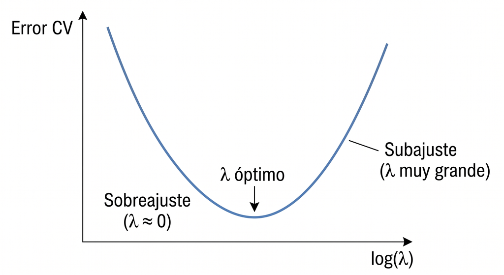

- λ pequeño → muchas variables, riesgo de sobreajuste
- λ grande → pocas variables, riesgo de subajuste
- La curva en U nos muestra el punto medio donde el modelo generaliza mejor

## Validación cruzada (recordatorio)

- Ya la usamos en el Día 1 y en la sesión 2.1: en vez de una sola división train/test, la validación cruzada entrena y evalúa $k$ veces (rotando el fold de validación) y promedia las métricas, para una estimación más estable
- Acá la usamos para elegir $\lambda$: evaluamos cada valor candidato con CV y nos quedamos con el mejor
- En tidymodels: `folds <- vfold_cv(datos_train, v = 5)`; después `tune_grid()` la usa por dentro
- $k$ = 5 o 10 es lo habitual: buena estimación sin gastar demasiado cómputo

## Tuning de la penalización con tidymodels

```r
# 1. Modelo con penalty a ajustar (tune() = "búscalo con CV")
# mixture = 1 → LASSO. Para Elastic Net: mixture = tune() también
modelo_lasso_tune <- linear_reg(penalty = tune(), mixture = 1) |> set_engine("glmnet") |> set_mode("regression")

# 2. Workflow (mismo patrón que antes, ahora con penalty pendiente)
wf_lasso <- workflow() |> add_recipe(receta) |> add_model(modelo_lasso_tune)

# 3. Grilla de valores candidatos de penalty (λ) en escala log10
grilla_lambda <- grid_regular(penalty(range = c(-4, 0)), levels = 30)

# 4. Validación cruzada con 5 folds
folds <- vfold_cv(datos_train, v = 5)

# 5. Probar cada λ con CV (ahora le pasamos el workflow)
resultados <- tune_grid(wf_lasso,
  resamples = folds,
  grid = grilla_lambda,
  metrics = metric_set(rmse, rsq))

# 6. Seleccionar el mejor λ
mejor_lambda <- select_best(resultados, metric = "rmse")

# 7. Finalizar y evaluar en test (last_fit = fit en train + métricas en test)
resultado_final <- wf_lasso |>
  finalize_workflow(mejor_lambda) |>
  last_fit(split = datos_split,
           metrics = metric_set(rmse, rsq))

collect_metrics(resultado_final)
```

- `select_best()` da el λ con menor RMSE. Veremos una alternativa más parsimoniosa más adelante
- Para Elastic Net, marca también `mixture = tune()` y agrega `mixture(range = c(0, 1))` a la grilla con `levels = c(20, 5)` (20 de λ × 5 de α)
- Es el mismo patrón de tuning de la sesión 2.1; lo corren paso a paso en el laboratorio

## Del código anterior: ¿qué hacen los pasos 5 a 7?

- **Paso 5**, `tune_grid()`: prueba los 30 valores de λ de la grilla
- Para cada λ ajusta el modelo en los folds de validación cruzada y mide el error (RMSE, R²). Devuelve una tabla con el rendimiento de cada λ
- **Paso 6**, `select_best()`: mira esa tabla y elige el λ con el menor RMSE promedio entre folds
- **Paso 7**, `finalize_workflow()` + `last_fit()`: hasta acá el workflow tenía un hueco (`penalty = tune()`) y no se podía ajustar
- `finalize_workflow()` escribe el λ ganador en ese hueco; recién ahí `last_fit()` puede reajustar con todo el train y evaluar una sola vez en el test
- Más información en https://www.tidymodels.org/start/tuning/

**El λ se elige sin tocar el test:**

```
resultados        (rendimiento de
     │             cada λ, vía CV)
     │  select_best()
     ▼
mejor_lambda      (un solo valor)
     │  finalize_workflow()
     │  + last_fit()
     ▼
resultado_final   (métricas en test)
```

La grilla y la CV eligen λ; el test set entra recién en el paso 7, una sola vez, para la métrica final

## Dos criterios para elegir λ

**λ mínimo** (`select_best`)

- El valor que minimiza el error de CV
- Mejor rendimiento predictivo
- Modelo más complejo (más variables)

```r
select_best(resultados, metric = "rmse")
```

**λ 1SE** (`select_by_one_std_err`)

- El λ más grande dentro de 1 error estándar del mínimo
- Modelo más parsimonioso
- Sacrifica un poco de rendimiento por simplicidad

```r
select_by_one_std_err(
  resultados,
  metric = "rmse",
  desc(penalty)
)
```

En ciencias sociales, el λ 1SE suele preferirse por producir modelos más interpretables

## Regularización en alta dimensionalidad

- Con $p > n$ hay infinitas soluciones que pasan por todos los puntos
- OLS no puede elegir entre ellas: deja coeficientes sin estimar y da un ajuste perfecto aunque los datos sean puro ruido
- La regularización rompe el empate: se queda con la de coeficientes más chicos (Ridge) o con la que usa menos variables (LASSO)
- Pasa con encuestas de cientos de ítems, registros administrativos y, sobre todo, análisis de texto: cada palabra es una variable. Lo ven mañana con TF-IDF
- LASSO/Ridge/Elastic Net dan una respuesta con $p > n$; OLS ni siquiera se puede calcular

**Una regla práctica:**

| Situación | Significado | Recomendación |
| --- | --- | --- |
| $n \gg p$ | Muchos datos, pocas variables | OLS probablemente está bien |
| $n \approx p$ | Datos y variables similares | Regularización ayuda |
| $n \ll p$ | Pocas observaciones, muchas variables | Regularización es necesaria (OLS no funciona) |

## Regularización también para clasificación

- LASSO, Ridge y Elastic Net no son solo para regresión
- Funcionan igual con regresión logística: se penalizan los coeficientes para evitar sobreajuste y seleccionar variables
- En tidymodels, basta con cambiar `linear_reg()` por `logistic_reg()`:

```r
# Regresión logística con LASSO
modelo_clasif <- logistic_reg(
  penalty = tune(),
  mixture = 1          # LASSO
) |>
  set_engine("glmnet") |>
  set_mode("classification")

# El resto del flujo es idéntico:
# workflow, recipe, tune_grid, etc.
```

**Ejemplo: predecir voto**

¿Qué variables predicen si alguien vota o no? Con 40 predictores de una encuesta, LASSO logístico selecciona los que realmente importan:

```
Variable              Coef
─────────────────────────────
edad                   0.52
educacion_anios        0.34
interes_politica       0.41
confianza_partidos     0.28
ingreso_hogar          0.00 ← eliminada
genero                 0.00 ← eliminada
satisf_servicios       0.00 ← eliminada
```

Misma lógica que antes: LASSO descarta las variables redundantes

# Aplicaciones en ciencias sociales

## Ejemplo: Predicción de pobreza con datos de encuestas

**El problema:**

- Los censos de pobreza son costosos y poco frecuentes
- Las encuestas de hogares tienen más detalle pero menos cobertura
- ¿Podemos predecir la pobreza en áreas sin datos usando características observables?

**Enfoque con LASSO:**

- Variable objetivo: ingreso per cápita (o indicador de pobreza)
- Predictores: características del hogar, vivienda, acceso a servicios
- LASSO selecciona las variables más predictivas
- El modelo se aplica a censos o registros administrativos

**Variables típicas seleccionadas:**

```
Variable              Coef LASSO
─────────────────────────────────
años_educacion_jefe    0.42
material_piso          0.28
acceso_agua_potable    0.22
num_habitaciones       0.18
tiene_refrigerador     0.15
material_techo         0.11
tiene_vehiculo         0.09
zona_urbana            0.00  ← eliminada
genero_jefe            0.00  ← eliminada
```

LASSO identifica automáticamente qué variables realmente predicen la pobreza

## Comparación

| Criterio | LASSO/Ridge/Elastic Net | Random Forest/Gradient Boosting |
| --- | --- | --- |
| Interpretabilidad | Alta (coeficientes) | Baja (importancia) |
| Relaciones no lineales | No | Sí |
| Interacciones | Manual | Automáticas |
| Selección de variables | Sí (LASSO) | No (pero da importancia) |
| Velocidad | Muy rápido | Moderado |
| Ajuste de hiperparámetros | 1-2 parámetros | Varios parámetros |
| Extrapolación | Lineal | No extrapola bien |

En la práctica, es útil probar ambos enfoques y comparar. La regularización es mejor cuando las relaciones son aproximadamente lineales y queremos interpretabilidad. RF es mejor cuando hay no linealidades e interacciones complejas

## ¿Cómo interpretar los coeficientes de LASSO?

- Tras ajustar un modelo LASSO, obtenemos un conjunto de coeficientes
- Algunos son exactamente cero: esas variables fueron eliminadas por el modelo
- Los que sobreviven son los predictores que LASSO consideró más relevantes

**¿Cómo leerlos?**

- Un coeficiente positivo indica que aumentar esa variable se asocia con un aumento en la respuesta
- Un coeficiente negativo indica lo contrario
- La magnitud depende de la escala de las variables. Si normalizamos antes (`step_normalize()`), los coeficientes son directamente comparables

**Atención:** LASSO elige una variable entre un grupo correlacionado y descarta las demás. No significa que las eliminadas no importen, sino que son redundantes con la que quedó

**Extraer coeficientes en tidymodels:**

```r
# Ajustar modelo final
ajuste_final <- fit(modelo_final,
                    satisfaccion ~ .,
                    data = datos_train)

# Ver coeficientes
tidy(ajuste_final) |>
  filter(estimate != 0) |>   # solo no-cero
  arrange(desc(abs(estimate)))
```

```
# Resultado (ejemplo):
term                  estimate
─────────────────────────────
confianza_gobierno     0.38
percepcion_economia    0.31
educacion_anios        0.22
edad                  -0.14
desempleo_regional    -0.09
```

Las variables con coeficiente = 0 (no mostradas) fueron descartadas por LASSO

## Resumen de la sesión

**Conceptos clave:**

- Predicción vs. explicación: objetivos diferentes, herramientas complementarias
- Regularización: LASSO selecciona, Ridge reduce, Elastic Net combina
- Ajuste de λ: siempre con validación cruzada, nunca con datos de test
- λ mínimo vs. λ 1SE: rendimiento vs. parsimonia

**Cuándo usar cada método:**

- OLS: pocos predictores, relaciones lineales, foco en explicación
- LASSO: muchos predictores, queremos selección automática
- Ridge: predictores correlacionados, no queremos eliminar ninguno
- Elastic Net: no estamos seguros, queremos lo mejor de ambos
- Random Forest/Gradient Boosting: mejor predicción posible, relaciones complejas

## Próximos pasos

- Laboratorios (2.3 y 2.4):
  - Clasificación con datos de Latinobarómetro
  - Regresión con datos socioeconómicos
  - Tuning de hiperparámetros en la práctica
  - Comparación e interpretación de modelos
- Mañana (Día 3): Aprendizaje no supervisado y análisis de texto
  - Clustering (K-means) y reducción de dimensionalidad (PCA)
  - Análisis computacional de texto
  - Topic modeling

¡Nos vemos en el laboratorio! 🤓

# ¡Nos vemos en el laboratorio! 😊